# Análisis Estadístico de Enfermedades en el Corazón

**Presenta:** Pablo César Rodríguez Aguayo

**Fecha:** 19/Junio/2019

**Materia:** Fundamentos de Estadística

# **Parte I**: Introducción

## Heart Disease UCI (Enfermedades del Corazón UCI)

Esta base de datos contiene 76 atributos, pero todos los experimentos publicados se refieren al uso de un subconjunto de 14 de ellos. En particular, la base de datos de Cleveland es la única que ha sido utilizada por los investigadores de Machine Learning hasta la fecha. El campo "objetivo" se refiere a la presencia de una enfermedad cardíaca en el paciente. Es un valor entero de 0 (sin presencia) a 4. Los experimentos con la base de datos de Cleveland se han concentrado en simplemente intentar distinguir la presencia (valores 1,2,3,4) de la ausencia (valor 0). Los nombres y números de seguridad social de los pacientes se eliminaron recientemente de la base de datos y se reemplazaron con valores ficticios.

## Problema Presentado

Dentro de la perspectiva social-sanitaria uno de los mayores retos que enfrentan las organizaciones de salud es la prestación de servicios los cuales permitan al paciente un costo bajo así como accesibilidad, con una calidad superior la cual garantice un diagnóstico objetivo. Un diagnóstico preciso comprende una toma de decisiones correcta la cual permita generar un diagnostico preciso para el paciente. Una decisión medica tomada de una forma no adecuada puede conducir a problemas mayores de salud donde cada vez se vuelven más costosos y difíciles de tratar, ya en última instancia pueden traer al paciente consecuencias desastrosas incluso llegando a la muerte. Habitualmente, las decisiones tomadas por el personal clínico a menudo son tomadas basándose en la intuición de los médicos y experiencia en lugar de las observaciones estadísticas de la información presentada, lo cual termina por llevar a errores de tratamiento, costos excesivos y efectos en la calidad de los servicios médicos de los pacientes.

## Significado del Diagnóstico

El diagnóstico de enfermedad cardíaca se realiza mediante una combinación de signos clínicos y resultados de pruebas. Los tipos de pruebas que se realizarán se elegirán en función de lo que el médico cree que está pasando, que va desde los electrocardiogramas y las tomografías computarizadas (TC) cardiacas hasta las pruebas de sangre y las pruebas de esfuerzo con ejercicios.

## Alcance del Estudio

Para propositos de esta investigación, se pretende realizar un análsis exploratorio de los factores que influyen sobre las enfermedades cardiacas. Lo cual permtirá posteriormente aplicar diversas técnicas de minería de datos para descubrir patrones dentro de los datos que nos permitan obtener mediciones y descripciones de los datos a través de la estadística descriptiva.

## Análisis Exploratorio de Datos

El análisis exploratorio de datos permitirá resumir las características que rodean el fenómeno en cuestión. La importancia del análisis exploratorio permite proporcionar y definir la percepcion del conjunto de datos utilizado. Permtiendo definir los objetivos a través del análisis de los datos mediante resumenes numéricos los cuales se enfocan en el aspecto estadístico. De igual manera, permiten enfocarse en los objetivos de la investigacion a través de la delimitación de los datos no necesarios.

## Recolección de Datos y Preprocesamiento

La recolección de datos y preprocesamiento estuvo a cargo de:

1. Hungarian Institute of Cardiology. Budapest: Andras Janosi, M.D.
2. University Hospital, Zurich, Switzerland: William Steinbrunn, M.D.
3. University Hospital, Basel, Switzerland: Matthias Pfisterer, M.D.
4. V.A. Medical Center, Long Beach and Cleveland Clinic Foundation: Robert Detrano, M.D., Ph.D.

Siendo donado por: David W. Aha (aha '@' ics.uci.edu) (714) 856-8779

Por lo que se desconocen los métodos de recolección y preprocesamiento empleados.

# **Parte II**: Análisis Exploratorio

## Análisis de las Características

### Librerías Necesarias

```r
library(knitr)
library(moments)
library(ggplot2)
library(GGally)

options(warn=-1)
```

### Descripción

```r
data <- read.csv(file = "../data/heart.csv", header = TRUE, sep = ",", stringsAsFactors=FALSE)
heart_data <- data.frame(data)
```

Dentro de las características del conjunto de datos, se presentan las siguientes:

- **age:** Edad en años.
- **sex:** Sexo como variable dicotómica (1 = masculino, 0 = femenino)
- **cp:** Tipo de dolor en el pecho.
- **trestbps:** Presión arterial en reposo (en mmHg al ingresar en el hospital)
- **chol:** Colesterol sérico en mg/dl
- **fbs:** Azúcar en la sangre en ayunas >120mg/dl (1 = verdadero, 0 = falso)
- **restecg:** Resultados electrocardiográficos en reposo.
- **thalach:** Ritmo Cardíaco Máximo Alcanzado
- **exang:** Angina Inducida por el Ejercicio
- **oldpeak:** Depresión ST inducida por el ejercicio en relación con el descanso.
- **slope:** La pendiente del segmento pico del ejercicio ST.
- **ca:** Número de vasos principales (0-3) coloreados por fluoroscopia
- **thal:** 3 = normal, 6 = defecto fijo, 7 = defecto reversible
- **target:** Enfermo = 1, no enfermo = 0.

### Cabecera

```r
head(data)
```

| age | sex | cp | trestbps | chol | fbs | restecg | thalach | exang | oldpeak | slope | ca | thal | target |
| --- | --- | --- | --- | --- | --- | --- | --- | --- | --- | --- | --- | --- | --- |
| 63 | 1 | 3 | 145 | 233 | 1 | 0 | 150 | 0 | 2.3 | 0 | 0 | 1 | 1 |
| 37 | 1 | 2 | 130 | 250 | 0 | 1 | 187 | 0 | 3.5 | 0 | 0 | 2 | 1 |
| 41 | 0 | 1 | 130 | 204 | 0 | 0 | 172 | 0 | 1.4 | 2 | 0 | 2 | 1 |
| 56 | 1 | 1 | 120 | 236 | 0 | 1 | 178 | 0 | 0.8 | 2 | 0 | 2 | 1 |
| 57 | 0 | 0 | 120 | 354 | 0 | 1 | 163 | 1 | 0.6 | 2 | 0 | 2 | 1 |
| 57 | 1 | 0 | 140 | 192 | 0 | 1 | 148 | 0 | 0.4 | 1 | 0 | 1 | 1 |

### Cola

```r
tail(data, 5)
```

|  | age | sex | cp | trestbps | chol | fbs | restecg | thalach | exang | oldpeak | slope | ca | thal | target |
| --- | --- | --- | --- | --- | --- | --- | --- | --- | --- | --- | --- | --- | --- | --- |
| 299 | 57 | 0 | 0 | 140 | 241 | 0 | 1 | 123 | 1 | 0.2 | 1 | 0 | 3 | 0 |
| 300 | 45 | 1 | 3 | 110 | 264 | 0 | 1 | 132 | 0 | 1.2 | 1 | 0 | 3 | 0 |
| 301 | 68 | 1 | 0 | 144 | 193 | 1 | 1 | 141 | 0 | 3.4 | 1 | 2 | 3 | 0 |
| 302 | 57 | 1 | 0 | 130 | 131 | 0 | 1 | 115 | 1 | 1.2 | 1 | 1 | 3 | 0 |
| 303 | 57 | 0 | 1 | 130 | 236 | 0 | 0 | 174 | 0 | 0.0 | 1 | 1 | 2 | 0 |

El conjunto de datos está conformado por 14 características y 303 observaciones.

## Máximos y Mínimos

Como se ha observado, el conjunto de datos tiene un número considerable de valores por lo que una de las metas es describir estas características y obtener una conclusión. El uso de máximos y mínimos permite el cálculo de otras medidas como el rango el cual se verá posteriormente. Además permite determinar los valores atípicos dentro del conjunto de datos, ya sean los valores atípicos menores o mayores.

```r
# --- age ---
women_age <- subset(heart_data, sex == 0)[c(1)]
men_age <- subset(heart_data, sex == 1)[c(1)]

# --- trestbps ---
women_trestbps <- subset(heart_data, sex == 0)[c(4)]
men_trestbps <- subset(heart_data, sex == 1)[c(4)]

# --- chol ---
women_chol <- subset(heart_data, sex == 0)[c(5)]
men_chol <- subset(heart_data, sex == 1)[c(5)]

# --- thalach ---
women_thalach <- subset(heart_data, sex == 0)[c(8)]
men_thalach <- subset(heart_data, sex == 1)[c(8)]

# --- oldpeak ---
women_oldpeak <- subset(heart_data, sex == 0)[c(10)]
men_oldpeak <- subset(heart_data, sex == 1)[c(10)]
```

### Máximos

A continuación se hace un análisis de los valores máximos de las variables: edad, presión arterial, colesterol, ritmo cardiaco y depresión de los pacientes. Separado por sexo, haciendo una comparación con el análisis en general.

```r
max_vals_men <- c(max(men_age$age), max(men_trestbps$trestbps), max(men_chol$chol), max(men_thalach$thalach), max(men_oldpeak$oldpeak))
max_vals_women <- c(max(women_age$age), max(women_trestbps$trestbps), max(women_chol$chol), max(women_thalach$thalach), max(women_oldpeak$oldpeak))
max_vals_general <- c(max(heart_data$age), max(heart_data$trestbps), max(heart_data$chol), max(heart_data$thalach), max(heart_data$oldpeak))

data_gen <- cbind(max_vals_general ,max_vals_men, max_vals_women)
df.max_val <- data.frame(data_gen)
colnames(df.max_val) <- sex_ <- c('General', 'Hombre', 'Mujer')
rownames(df.max_val) <- c('Edad', 'Presión Arterial', 'Colesterol', 'Ritmo Cardíaco', 'Depresión ST')

df.max_val
```

|  | General | Hombre | Mujer |
| --- | --- | --- | --- |
| Edad | 77.0 | 77.0 | 76.0 |
| Presión Arterial | 200.0 | 192.0 | 200.0 |
| Colesterol | 564.0 | 353.0 | 564.0 |
| Ritmo Cardíaco | 202.0 | 202.0 | 192.0 |
| Depresión ST | 6.2 | 5.6 | 6.2 |

**Comentarios:** Cabe destacar que de lo anterior visto, la *edad* máxima es perteneciente a los hombres por un año. En cuanto a *presión arterial*, se puede ver que el valor mayor corresponde a una mujer tomando el valor de 200, siendo el máximo en hombres menor por 8 unidades. Así mismo pasa con el *colesterol*, siendo el valor máximo encontrado en el subconjunto de las mujeres tomando el valor de 564 y en hombres de 353. Dada la naturaleza aún no estudiada del colesterol, hasta este punto pudiera ser que el colesterol máximo encontrado es un valor atípico. Respecto al *ritmo cardiaco*, se puede apreciar que es mayor en los hombres con un valor de 202, mientras que en mujeres es 10 unidades menor. Por último, se puede ver que en la depresión post-entrenamiento es ligeramente mayor en mujeres por 0.6, tomando las mujeres el valor máximo nuevamente. Hasta este punto, basandose en los aspectos analizados se puede ver que las mujeres tienen los valores máximos en tres de cinco características analizadas, siendo una de ellas un probable valor atípico.

### Mínimos

Se define como el valor matemático menor en el conjunto de datos.

```r
min_vals_men <- c(min(men_age$age), min(men_trestbps$trestbps), min(men_chol$chol), min(men_thalach$thalach), min(men_oldpeak$oldpeak))
min_vals_women <- c(min(women_age$age), min(women_trestbps$trestbps), min(women_chol$chol), min(women_thalach$thalach), min(women_oldpeak$oldpeak))
min_vals_general <- c(min(heart_data$age), min(heart_data$trestbps), min(heart_data$chol), min(heart_data$thalach), min(heart_data$oldpeak))

data_gen <- cbind(min_vals_general ,min_vals_men, min_vals_women)
df.min_val <- data.frame(data_gen)
colnames(df.min_val) <- sex_ <- c('General', 'Hombre', 'Mujer')
rownames(df.min_val) <- c('Edad', 'Presión Arterial', 'Colesterol', 'Ritmo Cardíaco', 'Depresión ST')

df.min_val
```

|  | General | Hombre | Mujer |
| --- | --- | --- | --- |
| Edad | 29 | 29 | 34 |
| Presión Arterial | 94 | 94 | 94 |
| Colesterol | 126 | 126 | 141 |
| Ritmo Cardíaco | 71 | 71 | 96 |
| Depresión ST | 0 | 0 | 0 |

**Comentarios:** De acuerdo a los valores mínimos, respecto a la *edad* podemos decir que siendo el valor mínimo perteneciente a un hombre con 29 años y el valor máximo a un hombre igualmente, se puede decir que es más ámplio el rango de edades en los varones. Para este caso, la *presión arterial*, presentó un caso con un valor mínimo de 94 tanto para hombres como para mujeres. Para el *colesterol* se puede ver que el valor mínimo se encuentra en el subconjunto de los hombres, con un valor de 126, mientras que las mujeres poseen un valor mínimo de 141. Para el caso del *ritmo cardiaco*, la presencia en hombres es con un valor mínimo de 71, mientras que en el subconjunto de las mujeres es de 96. Por último, se puede ver que para la depresión post-entrenamiento, el valor para todos es 0, lo cual puede ser un posible valor atípico encontrado dentro del conjunto de datos.

## Cuartiles, Percentiles y Valores Atípicos

### Cuartiles

En términos generales, los cuartiles dividen el conjunto de datos en cuatro partes iguales, con observaciones sobre el tercer cuartil que constituyen el cuarto superior de los datos del conjunto, siendo el segundo cuartil idéntico a la mediana, y el primer cuartil separado al cuarto más bajo de los tres cuartos superiores. Los valores comunmente esperados se encuentran entre el primer cuartil y el tercero, mientras que los valores atípicos se encuentran ya sea por encima del tercer cuartil o bien por debajo del primer cuartil. A continuación se hace el análisis de los cuartiles de los atributos.

#### Cuartiles Mujeres

```r
q_vals_women <- data.frame(
    quantile(women_age$age),
    quantile(women_trestbps$trestbps),
    quantile(women_chol$chol),
    quantile(women_thalach$thalach),
    quantile(women_oldpeak$oldpeak)
)

colnames(q_vals_women) <- c('Edad', 'Presión Arterial', 'Colesterol', 'Ritmo Cardíaco', 'Depresión ST')
q_vals_women
```

|  | Edad | Presión Arterial | Colesterol | Ritmo Cardíaco | Depresión ST |
| --- | --- | --- | --- | --- | --- |
| 0% | 34.00 | 94 | 141.00 | 96.00 | 0.0 |
| 25% | 49.75 | 120 | 214.75 | 141.25 | 0.0 |
| 50% | 57.00 | 131 | 253.00 | 157.00 | 0.6 |
| 75% | 63.00 | 140 | 296.75 | 165.00 | 1.4 |
| 100% | 76.00 | 200 | 564.00 | 192.00 | 6.2 |

#### Cuartiles Hombres

```r
q_vals_men <- data.frame(
    quantile(men_age$age),
    quantile(men_trestbps$trestbps),
    quantile(men_chol$chol),
    quantile(men_thalach$thalach),
    quantile(men_oldpeak$oldpeak)
)

colnames(q_vals_men) <- c('Edad', 'Presión Arterial', 'Colesterol', 'Ritmo Cardíaco', 'Depresión ST')
q_vals_men
```

|  | Edad | Presión Arterial | Colesterol | Ritmo Cardíaco | Depresión ST |
| --- | --- | --- | --- | --- | --- |
| 0% | 29.0 | 94 | 126 | 71 | 0.0 |
| 25% | 47.0 | 120 | 208 | 132 | 0.0 |
| 50% | 54.0 | 130 | 235 | 151 | 0.8 |
| 75% | 59.5 | 140 | 268 | 168 | 1.8 |
| 100% | 77.0 | 192 | 353 | 202 | 5.6 |

#### Cuartiles de Diagnóstico en General

```r
q_vals_general <- data.frame(
    quantile(heart_data$age),
    quantile(heart_data$trestbps),
    quantile(heart_data$chol),
    quantile(heart_data$thalach),
    quantile(heart_data$oldpeak)
)

colnames(q_vals_general) <- c('Edad', 'Presión Arterial', 'Colesterol', 'Ritmo Cardíaco', 'Depresión ST')
q_vals_general
```

|  | Edad | Presión Arterial | Colesterol | Ritmo Cardíaco | Depresión ST |
| --- | --- | --- | --- | --- | --- |
| 0% | 29.0 | 94 | 126.0 | 71.0 | 0.0 |
| 25% | 47.5 | 120 | 211.0 | 133.5 | 0.0 |
| 50% | 55.0 | 130 | 240.0 | 153.0 | 0.8 |
| 75% | 61.0 | 140 | 274.5 | 166.0 | 1.6 |
| 100% | 77.0 | 200 | 564.0 | 202.0 | 6.2 |

### Percentiles

Del mismo modo, un conjunto de datos se puede dividir aún más finamente usando percentiles; el percentil 99 separa el 1% más alto del 99% inferior, y así sucesivamente. A menos que el número de observaciones sea múltiplo de 100.

**Nota:** El percentil en la posición 50, el segundo cuartil, la mediana y el quinto decil son el mismo valor el cual está representado mediante la siguiente fórmula.

$$P_{50} = \tilde{x} = Q_2 = D_5$$

A continuación analizaremos los percentiles desde la perspectiva de un deciles.

#### Percentiles en Mujeres

```r
q_vals_women <- data.frame(
    quantile(women_age$age, c(.10, .20, .30, .40, .50, .60, .70, .80, .90, 1.0)),
    quantile(women_trestbps$trestbps, c(.10, .20, .30, .40, .50, .60, .70, .80, .90, 1.0)),
    quantile(women_chol$chol, c(.10, .20, .30, .40, .50, .60, .70, .80, .90, 1.0)),
    quantile(women_thalach$thalach, c(.10, .20, .30, .40, .50, .60, .70, .80, .90, 1.0)),
    quantile(women_oldpeak$oldpeak, c(.10, .20, .30, .40, .50, .60, .70, .80, .90, 1.0))
)

colnames(q_vals_women) <- c('Edad', 'Presión Arterial', 'Colesterol', 'Ritmo Cardíaco', 'Depresión ST')
q_vals_women
```

|  | Edad | Presión Arterial | Colesterol | Ritmo Cardíaco | Depresión ST |
| --- | --- | --- | --- | --- | --- |
| 10% | 42.0 | 109.0 | 197.0 | 121.5 | 0.0 |
| 20% | 46.0 | 120.0 | 209.0 | 133.0 | 0.0 |
| 30% | 51.0 | 121.0 | 224.0 | 144.0 | 0.0 |
| 40% | 54.0 | 130.0 | 240.0 | 152.0 | 0.2 |
| 50% | 57.0 | 131.0 | 253.0 | 157.0 | 0.6 |
| 60% | 59.0 | 136.0 | 268.0 | 160.0 | 0.9 |
| 70% | 62.0 | 140.0 | 285.5 | 163.0 | 1.2 |
| 80% | 64.0 | 146.0 | 305.0 | 169.0 | 1.5 |
| 90% | 66.5 | 157.5 | 335.0 | 172.0 | 2.0 |
| 100% | 76.0 | 200.0 | 564.0 | 192.0 | 6.2 |

#### Percentiles en Hombres

```r
q_vals_men <- data.frame(
    quantile(men_age$age, c(.10, .20, .30, .40, .50, .60, .70, .80, .90, 1.0)),
    quantile(men_trestbps$trestbps, c(.10, .20, .30, .40, .50, .60, .70, .80, .90, 1.0)),
    quantile(men_chol$chol, c(.10, .20, .30, .40, .50, .60, .70, .80, .90, 1.0)),
    quantile(men_thalach$thalach, c(.10, .20, .30, .40, .50, .60, .70, .80, .90, 1.0)),
    quantile(men_oldpeak$oldpeak, c(.10, .20, .30, .40, .50, .60, .70, .80, .90, 1.0))
)

colnames(q_vals_men) <- c('Edad', 'Presión Arterial', 'Colesterol', 'Ritmo Cardíaco', 'Depresión ST')
q_vals_men
```

|  | Edad | Presión Arterial | Colesterol | Ritmo Cardíaco | Depresión ST |
| --- | --- | --- | --- | --- | --- |
| 10% | 42 | 110 | 185.6 | 113.6 | 0.0 |
| 20% | 45 | 120 | 203.2 | 127.2 | 0.0 |
| 30% | 49 | 120 | 213.8 | 140.0 | 0.0 |
| 40% | 52 | 125 | 227.4 | 144.0 | 0.4 |
| 50% | 54 | 130 | 235.0 | 151.0 | 0.8 |
| 60% | 57 | 132 | 247.0 | 158.0 | 1.2 |
| 70% | 59 | 140 | 260.0 | 163.0 | 1.6 |
| 80% | 61 | 142 | 275.8 | 171.0 | 2.0 |
| 90% | 65 | 152 | 299.0 | 178.4 | 2.8 |
| 100% | 77 | 192 | 353.0 | 202.0 | 5.6 |

#### Percentiles de Diagnóstico en General

```r
q_vals_general <- data.frame(
    quantile(heart_data$age, c(.10, .20, .30, .40, .50, .60, .70, .80, .90, 1.0)),
    quantile(heart_data$trestbps, c(.10, .20, .30, .40, .50, .60, .70, .80, .90, 1.0)),
    quantile(heart_data$chol, c(.10, .20, .30, .40, .50, .60, .70, .80, .90, 1.0)),
    quantile(heart_data$thalach, c(.10, .20, .30, .40, .50, .60, .70, .80, .90, 1.0)),
    quantile(heart_data$oldpeak, c(.10, .20, .30, .40, .50, .60, .70, .80, .90, 1.0))
)

colnames(q_vals_general) <- c('Edad', 'Presión Arterial', 'Colesterol', 'Ritmo Cardíaco', 'Depresión ST')
q_vals_general
```

|  | Edad | Presión Arterial | Colesterol | Ritmo Cardíaco | Depresión ST |
| --- | --- | --- | --- | --- | --- |
| 10% | 42 | 110 | 188.0 | 116.0 | 0.00 |
| 20% | 45 | 120 | 204.0 | 130.0 | 0.00 |
| 30% | 50 | 120 | 217.6 | 140.6 | 0.00 |
| 40% | 53 | 126 | 230.0 | 146.0 | 0.38 |
| 50% | 55 | 130 | 240.0 | 153.0 | 0.80 |
| 60% | 58 | 134 | 254.0 | 159.0 | 1.12 |
| 70% | 59 | 140 | 268.0 | 163.0 | 1.40 |
| 80% | 62 | 144 | 285.2 | 170.0 | 1.90 |
| 90% | 66 | 152 | 308.8 | 176.6 | 2.80 |
| 100% | 77 | 200 | 564.0 | 202.0 | 6.20 |

### Valores Atípicos

Se definen como los valores mucho mayores o menores que los demás valores en el conjunto de datos. O bien, se puede definir como el valor que radica por fuera del conjunto de datos establecido las cuales se distinguen por su distancia a los valores normales.

#### Regla del Pulgar

Siendo una práctica común la *regla del pulgar*, consiste en designar un valor atípico en base a la experiencia obtenida. Para esto, los valores atípicos se calculan mediante dos fórmulas. La primera permite calcular los valores atípicos mínimos, es decir los valores que están por debajo de lo esperado, para esto se emplea la siguiente fórmula:

$$V_{ai} = Q_1 - 1.5*IQR$$

Donde:

- $V_{ai}$ son los valores atípicos inferiores.
- $Q_1$ es el valor del cuartil 1.
- $IQR$ es el valor intercuartil.

Mientras que para calcular los valores atípicos por encima de lo esperado, se emplea la siguiente fórmula:

$$V_{as} = Q_3 + 1.5*IQR$$

Donde:

- $V_{as}$ son los valore atípicos superiores.
- $Q_3$ es el valor del cuartil 3.
- $IQR$ es el valor intercuartil.

Si bien estas medidas no son utilizadas como la forma adecuada para calcular los valores atípicos, dentro de la industrial son ampliamente aceptadas. Sin embargo, estos métodos solo son usados si el analista de datos es considerado de grado midlevel o senior. Para este caso se utilizará el diagrama de caja para ver la distribución de los datos. Para visualizar los valores atípicos se utilizará el diagrama de caja, este permitirá ver el comportamiento dentro del atributo de los datos.

### Rango

El rango permite conocer la diferencia entre el valor máximo y mínimo de la característica seleccionada. Esta medida es considerada como medida de dispersión y permite conocer el intervalo que se haya entre la distribución. Se calcula mediante la siguiente fórmula:

$$R_{var} = max(x) - min(x)$$

### Indicaciones Generales

A continuación se realizará un análisis para las características: edad y presión arterial. Mostrando los valores mínimos, máximo, rango segundo cuartil, obteniendo un breve análisis de los datos obtenidos.

#### Edad

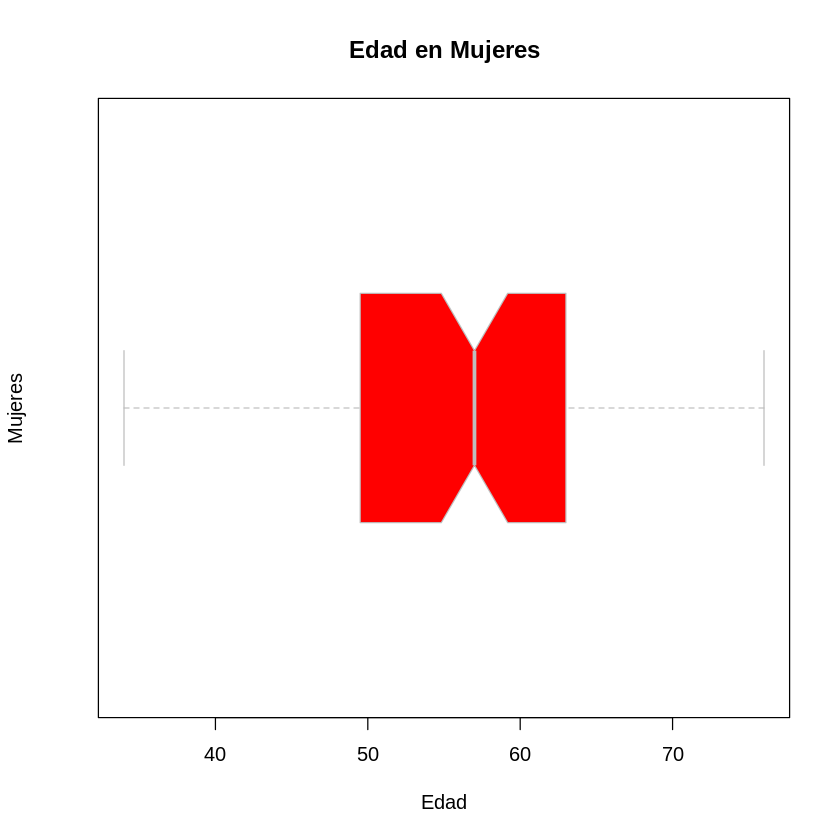

```r
boxplot(women_age$age,
  main = "Edad en Mujeres",
  xlab = "Edad",
  ylab = "Mujeres",
  col = "red",
  border = "gray",
  horizontal = TRUE,
  notch = TRUE
)
```

**Comentarios:** De acuerdo a la gráfica anterior se puede apreciar que el valor mínimo está en 34 mientras que su máximo es de 76, con un rango de 42. A su vez se puede apreciar que no hay valores atípicos y que su segundo cuartil es de 57.

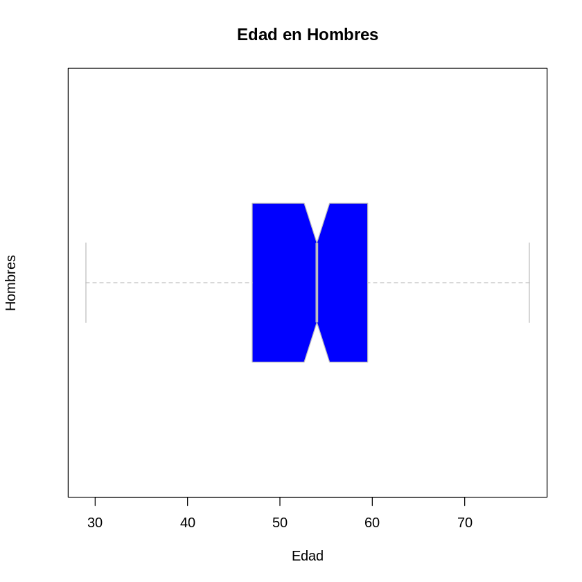

```r
boxplot(men_age$age,
  main = "Edad en Hombres",
  xlab = "Edad",
  ylab = "Hombres",
  col = "blue",
  border = "gray",
  horizontal = TRUE,
  notch = TRUE
)
```

**Comentarios:** Para el conjunto de los hombres se puede apreciar un valor mínimo de 29 y un máximo de 77, donde su rango es de 48. A su vez se puede apreciar que no hay valores atípicos y que su segundo cuartil es de 54, esto debido al mayor rango de los datos.

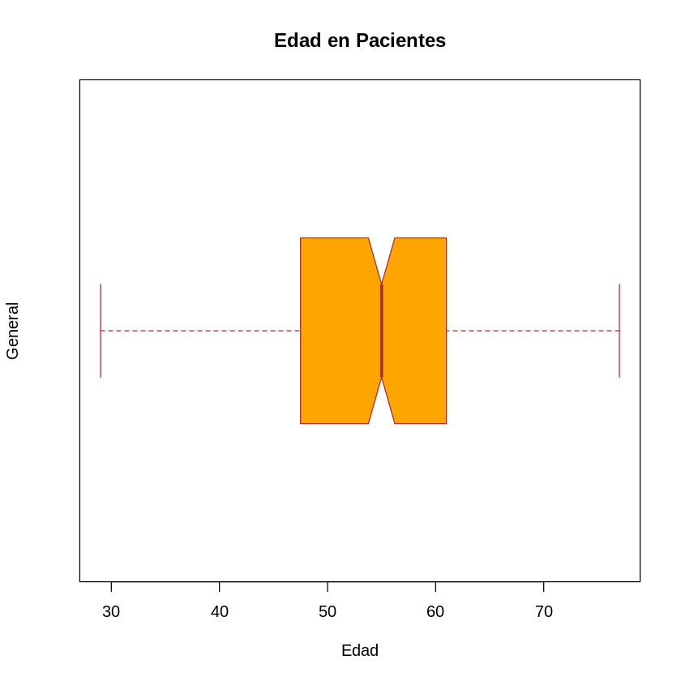

```r
boxplot(heart_data$age,
  main = "Edad en Pacientes",
  xlab = "Edad",
  ylab = "General",
  col = "orange",
  border = "brown",
  horizontal = TRUE,
  notch = TRUE
)
```

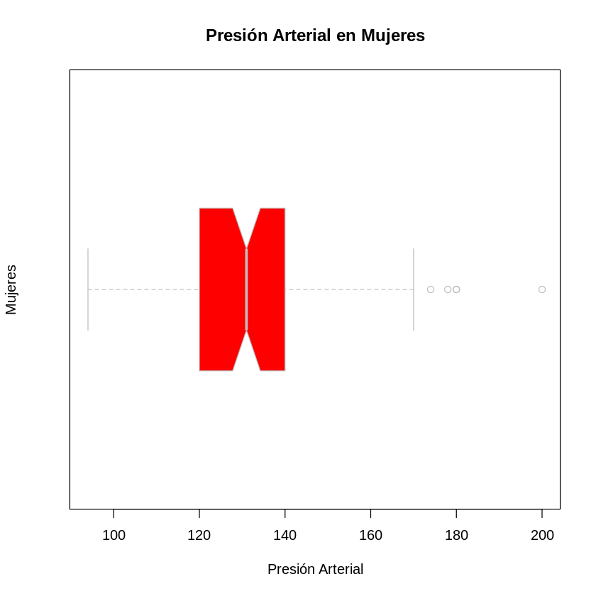

```r
boxplot(women_trestbps$trestbps,
  main = "Presión Arterial en Mujeres",
  xlab = "Presión Arterial",
  ylab = "Mujeres",
  col = "red",
  border = "gray",
  horizontal = TRUE,
  notch = TRUE
)
```

**Comentarios:** En el subconjunto de las mujeres se puede apreciar un valor mínimo de 94 y un máximo de 200, donde su rango es de 106. Presentando valores atípicos despues del tercer quartil y con segundo cuartil de 131 indicando la mitad de los datos.

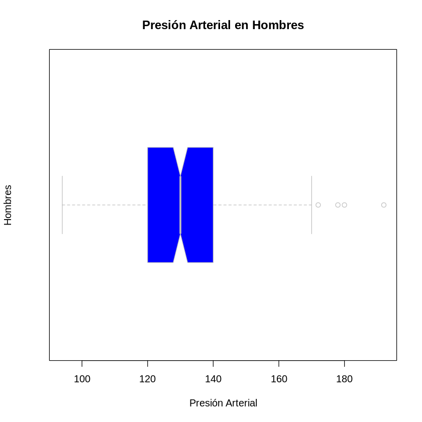

```r
# --- trestbps ---
boxplot(men_trestbps$trestbps,
  main = "Presión Arterial en Hombres",
  xlab = "Presión Arterial",
  ylab = "Hombres",
  col = "blue",
  border = "gray",
  horizontal = TRUE,
  notch = TRUE
)
```

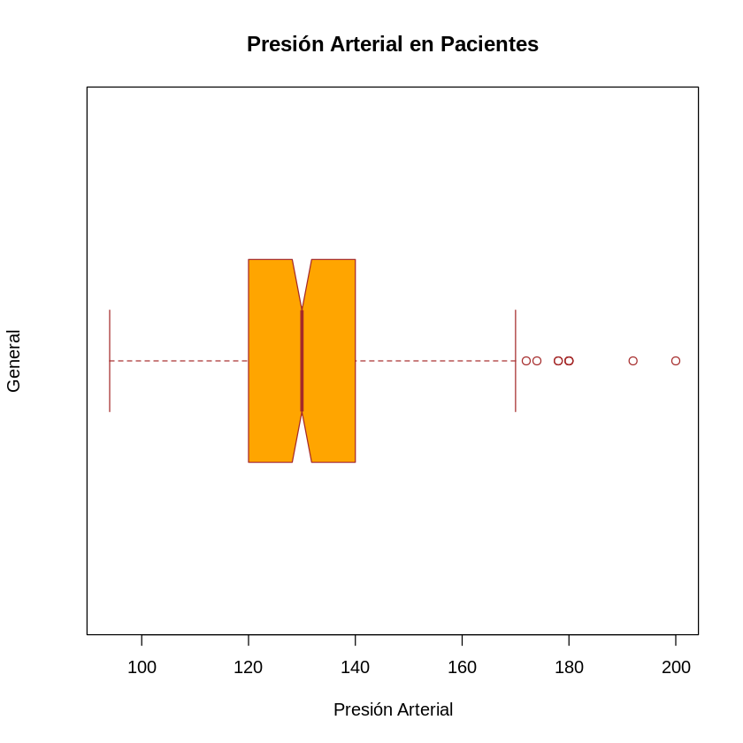

```r
# --- trestbps ---
boxplot(heart_data$trestbps,
  main = "Presión Arterial en Pacientes",
  xlab = "Presión Arterial",
  ylab = "General",
  col = "orange",
  border = "brown",
  horizontal = TRUE,
  notch = TRUE
)
```

**Comentarios:** Por último, en el conjunto general se puede ver un valor mínimo de 94 y un máximo de 200 con un rango de 106. Presentando valores atípicos después del tercer cuartil y un segundo cuartil de 130.

## Medidas de Tendencia Central

Las medidas de tendencia central permiten obtener indicadores preeliminares que brindan una interpretación numérica de las medidas obtenidas.

### Media

Primer momento alrededor del cero es la media o valor esperado de la variable aleatoria y se denota por $\mu$. La media de una variable aleatoria se considera como una cantidad numérica alrededor de la cual los valores de la variable aleatoria tienden a agruparse. Por lo tanto, la media es una medida de tendencia central. Para el cálculo de la media se utiliza:

$$\bar{x}=\frac{1}{n}\sum_{i=1}^n x_i$$

### Mediana

La mediana en un conjunto de datos es el valor medio cuando los valores son ordenados de manera ascendente o descendente. Igualmente, en este punto será calculada la mediana para futuras referencias, si $n$ es par entonces se calcula mediante:

$$\tilde{x} = x_{(n + 1)/2}$$

Por otro lado si $n$ es impar se calcula:

$$\tilde{x} = x_{(n + 1)/2} + x_{n/2}$$

### Moda

La moda es un término estadístico que se refiere al número que aparece con mayor frecuencia en un conjunto de números. Esta se encuentra al recopilar y organizar datos para contar la frecuencia de cada resultado. Donde radica sobre su recuento más alto de ocurrencias del conjunto, igualmente se le conoce como el valor modal.

$$\text{Varlor repetido con más frecuencia}$$

### Conclusiones Generales

#### Colesterol

| Media | Mediana |
| --- | --- |
| 261.3021 | 253 |

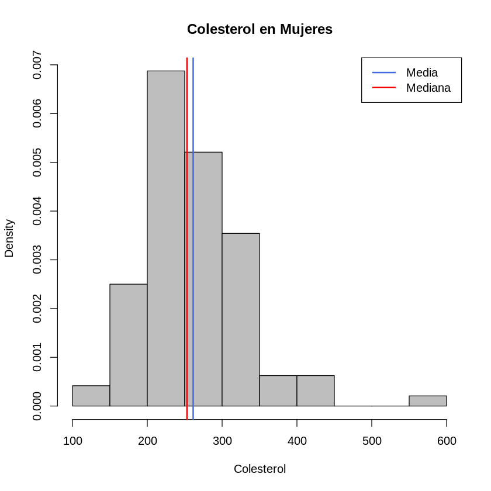

```r
Mode <- function(x) {
  ta = table(x)
    tam = max(ta)
    if (all(ta == tam))
         mod = NA
    else
         if(is.numeric(x))
    mod = as.numeric(names(ta)[ta == tam])
    else
         mod = names(ta)[ta == tam]
    return(mod)
}

# --- trestbps ---
hist(women_chol$chol,
  col = "gray",
  border = "black",
  prob = TRUE,
  xlab = "Colesterol",
  main = "Colesterol en Mujeres")
  abline(v = mean(women_chol$chol),   col = "royalblue", lwd = 2)
  abline(v = median(women_chol$chol), col = "red", lwd = 2)
  legend(x = "topright",
    c("Media", "Mediana"),
    col = c("royalblue", "red",  "yellow"),
    lwd = c(2, 2, 2)
)

# --- Tabla ---
table_women_chol <- data.frame(
  mean(women_chol$chol),
  median(women_chol$chol)
)

colnames(table_women_chol) <- c('Media', 'Mediana')
table_women_chol
```

| Media | Mediana |
| --- | --- |
| 239.2899 | 235 |

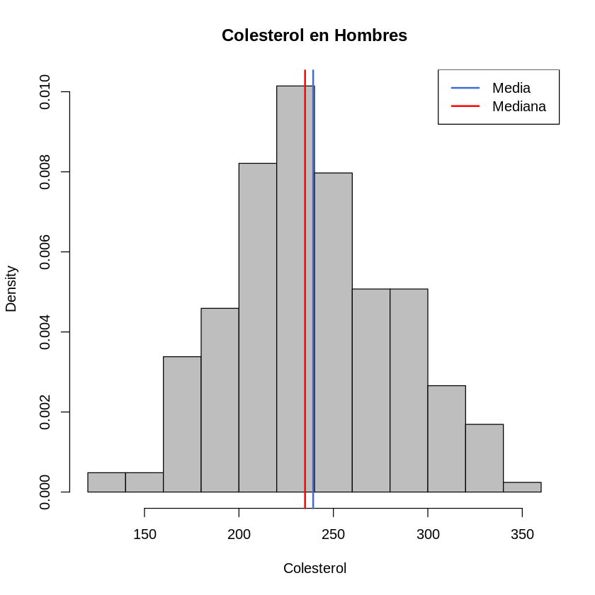

```r
# --- trestbps ---
hist(men_chol$chol,
  col = "gray",
  border = "black",
  prob = TRUE,
  xlab = "Colesterol",
  main = "Colesterol en Hombres")
  abline(v = mean(men_chol$chol),   col = "royalblue", lwd = 2)
  abline(v = median(men_chol$chol), col = "red", lwd = 2)

legend(x = "topright",
    c("Media", "Mediana"),
    col = c("royalblue", "red",  "yellow"),
    lwd = c(2, 2, 2)
)

# --- Tabla ---
table_men_chol <- data.frame(
  mean(men_chol$chol),
  median(men_chol$chol)
)

colnames(table_men_chol) <- c('Media', 'Mediana')
table_men_chol
```

**Comentarios:** Para esta gráfica se puede apreciar que se obtuvo una mediana media aún más cercanas, donde la media tuvo un valor de 239.28, por otro lado la mediana tuvo un valor de 235. Se puede observar que la diferencia entre ambas medidas sólo fue de 4.28 unidades. Cabe mencionar que esta gráfica se parece más a la distribución normal, la cual será vista posteriormente.|m

| Media | Mediana |
| --- | --- |
| 246.264 | 240 |

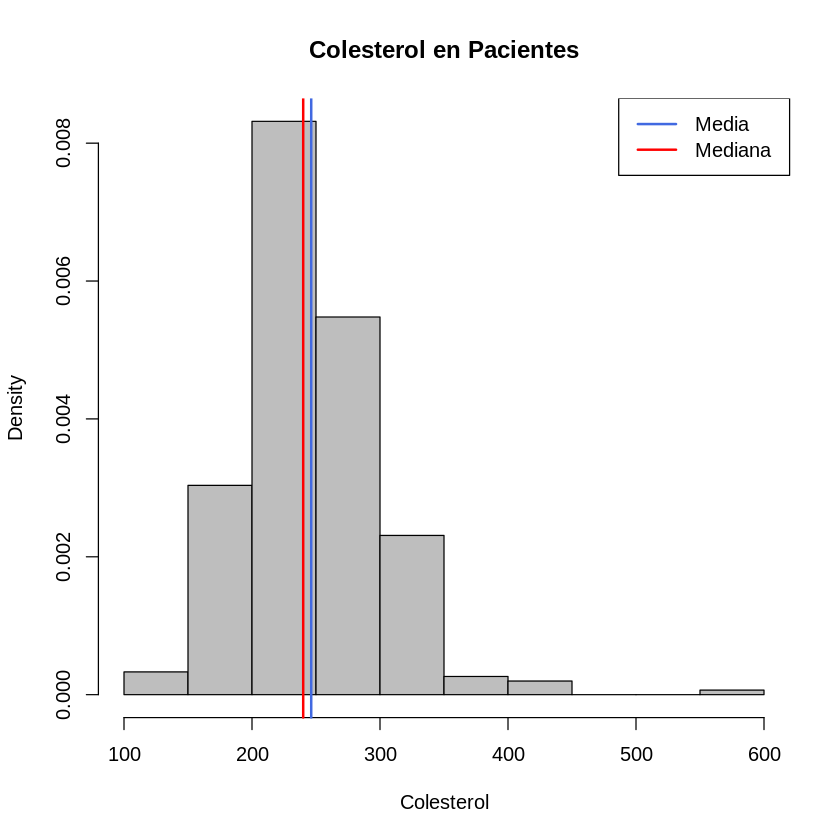

```r
hist(heart_data$chol, # histogram
  col = "gray", # column color
  border = "black",
  prob = TRUE, # show densities instead of frequencies
  xlab = "Colesterol",
  main = "Colesterol en Pacientes")

  abline(v = mean(heart_data$chol),   col = "royalblue", lwd = 2)
  abline(v = median(heart_data$chol), col = "red", lwd = 2)


legend(x = "topright",
    c("Media", "Mediana"),
    col = c("royalblue", "red",  "yellow"),
    lwd = c(2, 2, 2)
)

# --- Tabla ---
table_men_chol <- data.frame(
  mean(heart_data$chol),
  median(heart_data$chol)
)

colnames(table_men_chol) <- c('Media', 'Mediana')
table_men_chol
```

**Comentarios:** A partir del conjunto de datos en general, se puede apreciar que de acuerdo a la media la mediana es un valor por debajo por sólo 6.26 unidades. Donde la media fue superior en los tres casos presentados.

## Medidas de Dispersión

Las medidas distribución, permiten determinar que tan estirados o compactos están los datos del conjunto. Se puede ver que las medidas de dispersión estadística son la varianza y la desviación estándar son las más comunmente usadas. Estas medidas de dispersión contrastan la ubicación o tendencia central de los datos utilizados.

### Varianza

El segundo momento central,alrededor de la media, recibe el nombre de varianza de la variable aleatoria. La varianza de una variable aleatoria es una medida de la dispersión de la distribución de probabilidad de esta. La varianza puede representarse mediante la siguiente fórmula:

$$s^{2}=\frac{1}{N-1}\sum_{i=1}^N(x_i-\bar{x})^2$$

### Desviación Estándar

La desviación estándar es una medida estadística muestra la dispersión de un conjunto de datos en relación con su media y se calcula como la raíz cuadrada de la varianza. El cálculo realizado a través de la *varianza* permite determinar la variación entre cada punto de datos en relación con la media. Si los puntos de datos están más alejados de la media, hay una mayor desviación dentro del conjunto de datos; por lo tanto, cuanto más dispersos estén los datos, mayor será la desviación estándar. Su representación es la siguiente:

$$s=\sqrt{\frac{1}{N-1}\sum_{i=1}^N(x_i-\bar{x})^2}$$

O bien: $$s=\sqrt{s^2}$$

A continuación se realizará un análisis del ritmo cardiáco máximo alcanzado, donde se analizarán las medidas de dispersión y de tendencia central.

| Media | Mediana | Desviación Estándar |
| --- | --- | --- |
| 151.125 | 157 | 20.04797 |

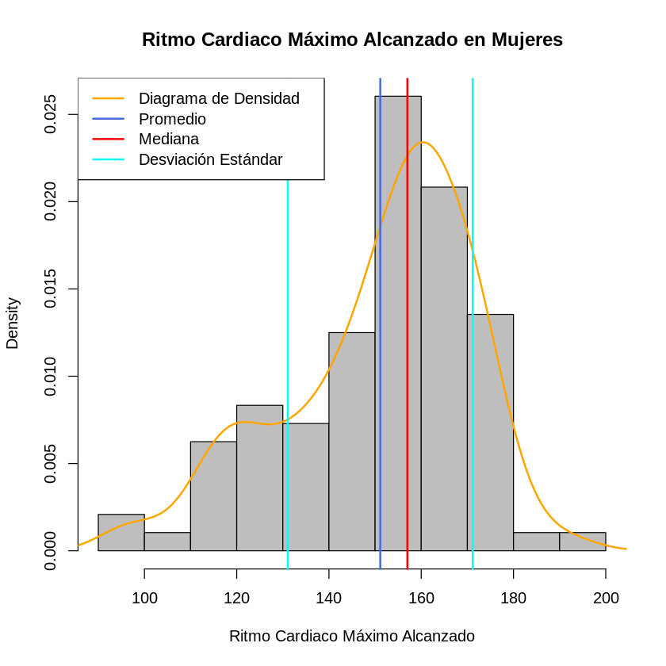

```r
# --- trestbps ---
hist(women_thalach$thalach, # histogram
  col = "gray", # column color
  border = "black",
  prob = TRUE, # show densities instead of frequencies
  xlab = "Ritmo Cardiaco Máximo Alcanzado",
  main = "Ritmo Cardiaco Máximo Alcanzado en Mujeres")

  lines(density(women_thalach$thalach), # density plot
  lwd = 2, # thickness of line
  col = "orange")

  abline(v = mean(women_thalach$thalach), col = "royalblue", lwd = 2)
  abline(v = median(women_thalach$thalach), col = "red", lwd = 2)
  abline(v = mean(women_thalach$thalach) + sd(women_thalach$thalach), col = "cyan", lwd = 2)
  abline(v = mean(women_thalach$thalach) - sd(women_thalach$thalach), col = "cyan", lwd = 2)

legend(x = "topleft", # location of legend within plot area
 c("Diagrama de Densidad", "Promedio", "Mediana", "Desviación Estándar"),
 col = c("orange", "royalblue", "red", "cyan"),
 lwd = c(2, 2, 2))

# --- Tabla ---
table_md_women_thalach <- data.frame(
  mean(women_thalach$thalach),
  median(women_thalach$thalach),
  sd(women_thalach$thalach)
)

colnames(table_md_women_thalach) <- c('Media', 'Mediana', 'Desviación Estándar')
table_md_women_thalach
```

**Comentarios:** La desviación estándar ayuda a determinar el tamaño de la dispersión de los datos en comparación con el valor medio. A medida que aumenta la variación, se producen más variaciones en los valores de los datos, y puede haber una brecha mayor entre un valor de datos y otro. Para este caso se puede ver que hay una desviación estándar de 20.04, lo cual indica una dispersión respecto a los datos amplia.

| Media | Mediana | Desviación Estándar |
| --- | --- | --- |
| 148.9614 | 151 | 24.13088 |

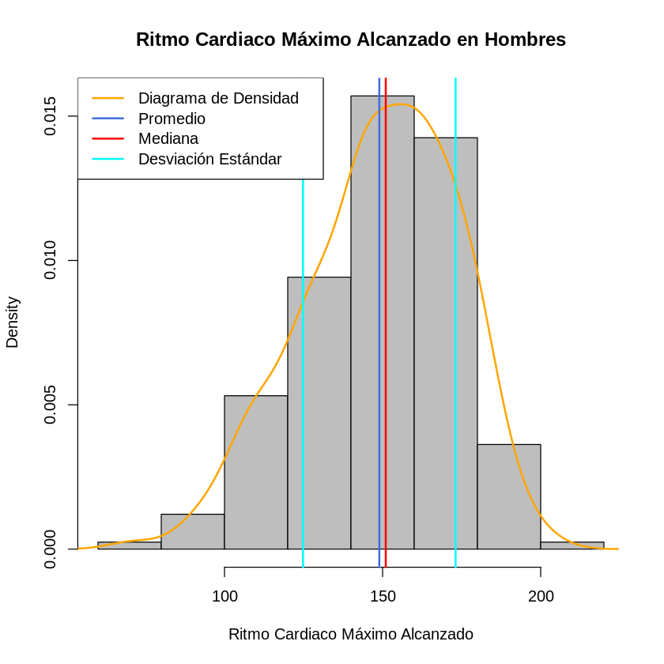

```r
# --- trestbps ---
hist(men_thalach$thalach, # histogram
col = "gray", # column color
border = "black",
prob = TRUE, # show densities instead of frequencies
xlab = "Ritmo Cardiaco Máximo Alcanzado",
main = "Ritmo Cardiaco Máximo Alcanzado en Hombres")

lines(density(men_thalach$thalach), # density plot
lwd = 2, # thickness of line
col = "orange")

abline(v = mean(men_thalach$thalach), col = "royalblue", lwd = 2)
abline(v = median(men_thalach$thalach), col = "red", lwd = 2)
abline(v = mean(men_thalach$thalach) + sd(men_thalach$thalach), col = "cyan", lwd = 2)
abline(v = mean(men_thalach$thalach) - sd(men_thalach$thalach), col = "cyan", lwd = 2)

legend(x = "topleft", # location of legend within plot area
 c("Diagrama de Densidad", "Promedio", "Mediana", "Desviación Estándar"),
 col = c("orange", "royalblue", "red", "cyan"),
 lwd = c(2, 2, 2))

# --- Tabla ---
table_men_thalach_ <- data.frame(
  mean(men_thalach$thalach),
  median(men_thalach$thalach),
  sd(men_thalach$thalach)
)

colnames(table_men_thalach_) <- c('Media', 'Mediana', 'Desviación Estándar')
table_men_thalach_
```

| Media | Mediana | Desviación Estándar |
| --- | --- | --- |
| 149.6469 | 153 | 22.90516 |

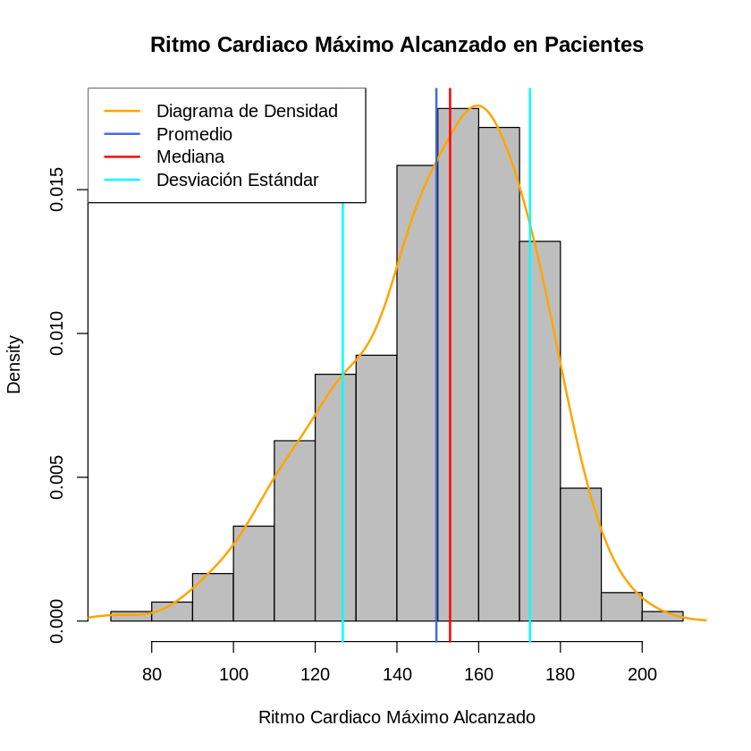

```r
# --- trestbps ---
hist(heart_data$thalach, # histogram
  col = "gray", # column color
  border = "black",
  prob = TRUE, # show densities instead of frequencies
  xlab = "Ritmo Cardiaco Máximo Alcanzado",
  main = "Ritmo Cardiaco Máximo Alcanzado en Pacientes")

  lines(density(heart_data$thalach), lwd = 2, col = "orange")

  abline(v = mean(heart_data$thalach), col = "royalblue", lwd = 2)
  abline(v = median(heart_data$thalach), col = "red", lwd = 2)
  abline(v = mean(heart_data$thalach) + sd(heart_data$thalach), col = "cyan", lwd = 2)
  abline(v = mean(heart_data$thalach) - sd(heart_data$thalach), col = "cyan", lwd = 2)

legend(x = "topleft",
  c("Diagrama de Densidad", "Promedio", "Mediana", "Desviación Estándar"),
  col = c("orange", "royalblue", "red", "cyan"),
  lwd = c(2, 2, 2)
)

# --- Tabla ---
table_men_chol <- data.frame(
  mean(heart_data$thalach),
  median(heart_data$thalach),
  sd(heart_data$thalach)
)

colnames(table_men_chol) <- c('Media', 'Mediana', 'Desviación Estándar')
table_men_chol
```

**Comentarios:** Por último, se puede observar que para los pacientes en general hay una desviación estándar de 22.9 unidades, con una mediana de 153 y una media de 149.64.

## Curtosis y Sesgo

### Curtosis

Las curtosis permite examinar la proporción de la varianza que se explica por la combinación de datos extremos respecto a la media en contraposición con datos poco alejados de la misma. Una mayor curtosis implica una mayor concentración de datos cerca de la media de la distribución elevando la frecuencia de datos muy alejados de la misma.

$$\alpha = \frac{\sum{(x_i - \bar{x}})^{4}}{ns^4}$$

A continuación se analizará la curtosis de los pacientes con el *ritmmo cardiaco máximo* y sus subconjuntos de hombres y mujeres.

```r
#install.packages('moments')
library(moments)
kurt_pac_thalach <- kurtosis(heart_data$thalach)
kurt_men_thalach <- kurtosis(men_thalach$thalach)
kurt_wom_thalach <- kurtosis(women_thalach$thalach)

data_kurt <- cbind(kurt_pac_thalach, kurt_men_thalach, kurt_wom_thalach)
df.kurt_val <- data.frame(data_kurt)
colnames(df.kurt_val) <- sex_ <- c('General', 'Hombre', 'Mujer')
rownames(df.kurt_val) <- c('Curtosis')

df.kurt_val
```

|  | General | Hombre | Mujer |
| --- | --- | --- | --- |
| Curtosis | 2.919311 | 2.810824 | 2.995223 |

**Comentarios:** Para este caso las tres curtosis son menores a tres, lo que representa una curtosis mesocurtica o platicurtica. Lo cual indica que tiene una distribución con menores registros de valores en los extremos, esto significa que la probabilidad de eventos extremos es mayor que lo que implica la curva normal. Es decir, la distribución mesocurtica tiene colas más claras, y su probabilidad de eventos extremos es menor que lo que implica la curva normal.

### Sesgo

Esta forma de distribución permite identificar la manera como los datos tienden a reunirse de acuerdo con la frecuencia con que se hallen dentro de la distribución. Las medidas de asimetría son indicadores que permiten establecer el grado de simetría que presentan una distribución de probabilidad de una variable aleatoria sin tener que hacer su representación gráfica.

$$A_s = \frac{3(\bar{x} - \tilde{x})}{s}$$

```r
skew_pac_thalach <- skewness(heart_data$thalach)
skew_men_thalach <- skewness(men_thalach$thalach)
skew_wom_thalach <- skewness(women_thalach$thalach)

data_skew <- cbind(skew_pac_thalach, skew_men_thalach, skew_wom_thalach)
df.skew_val <- data.frame(data_skew)
colnames(df.skew_val) <- sex_ <- c('General', 'Hombre', 'Mujer')
rownames(df.skew_val) <- c('Sesgo')

df.skew_val
```

|  | General | Hombre | Mujer |
| --- | --- | --- | --- |
| Sesgo | -0.5347455 | -0.44657 | -0.7496368 |

**Comentarios:** El analisis del sesgo para los pacientes en general indica que los datos están sesgados moderadamente, ya que su valor es menor que -0.5. Por otro lado, se puede apreciar que el sesgo para los hombres indica una distribución parcial de los datos ya que su valor es mayor a -0.5 y menor que 0.5. Por último, para el caso de las mujeres se puede apreciar que los datos están sesgados moderadamente ya que su valor es menor a -0.5, lo cual indica una distribución mayor de los datos.

## Correlación

La correlación mide la forma en la que dos medidas se relacionan, para esto se puede ver que hay tanto correlación positiva como negativa o también llamada inversa. La correlación positiva describe la relación entre dos variables que cambian juntas, mientras que una correlación inversa describe la relación entre dos variables que cambian en direcciones opuestas. La correlación inversa se describe a veces como correlación negativa, que describe el mismo tipo de relación entre las variables.

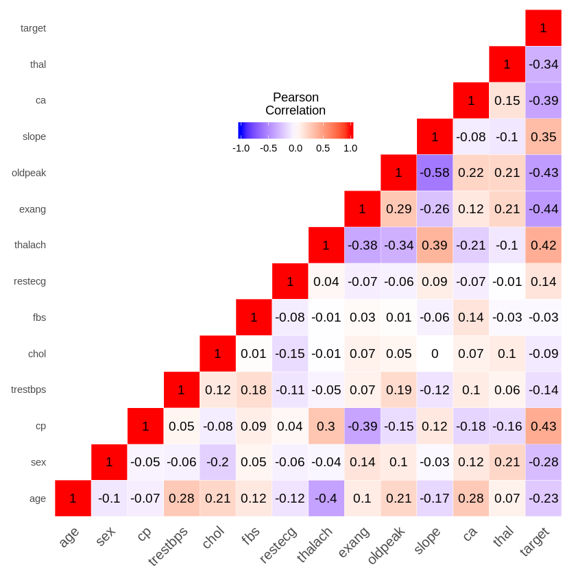

```r
cormat <- round(cor(heart_data),2)
library(reshape2)
melted_cormat <- melt(cormat)
#head(melted_cormat)

# Get lower triangle of the correlation matrix
  get_lower_tri<-function(cormat){
    cormat[upper.tri(cormat)] <- NA
    return(cormat)
  }
  # Get upper triangle of the correlation matrix
  get_upper_tri <- function(cormat){
    cormat[lower.tri(cormat)]<- NA
    return(cormat)
  }

upper_tri <- get_upper_tri(cormat)


library(reshape2)
melted_cormat <- melt(upper_tri, na.rm = TRUE)


# Create a ggheatmap
ggheatmap <- ggplot(melted_cormat, aes(Var2, Var1, fill = value))+
 geom_tile(color = "white")+
 scale_fill_gradient2(low = "blue", high = "red", mid = "white",
   midpoint = 0, limit = c(-1,1), space = "Lab",
    name="Pearson\nCorrelation") +
  theme_minimal()+ # minimal theme
 theme(axis.text.x = element_text(angle = 45, vjust = 1,
    size = 12, hjust = 1))+
 coord_fixed()

ggheatmap +
geom_text(aes(Var2, Var1, label = value), color = "black", size = 4) +
theme(
  axis.title.x = element_blank(),
  axis.title.y = element_blank(),
  panel.grid.major = element_blank(),
  panel.border = element_blank(),
  panel.background = element_blank(),
  axis.ticks = element_blank(),
  legend.justification = c(1, 0),
  legend.position = c(0.6, 0.7),
  legend.direction = "horizontal")+
  guides(fill = guide_colorbar(barwidth = 7, barheight = 1,
                title.position = "top", title.hjust = 0.5))
```

Cabe destacar que la correlación no necesariamente implica una causa, las variables A y B pueden subir y bajar juntas, o A puede aumentar a medida que B cae, pero no siempre es cierto que el aumento de un factor influye directamente en el aumento o la caída del otro. Ambos pueden ser causados por un tercer factor subyacente, como una variable C, o la relación aparente entre las variables podría ser una coincidencia.

### Análisis de Componentes Principales

El análisis de componentes principales(PCA), es un método de reducción de dimensionalidad que se usa para reducir la dimensionalidad de grandes conjuntos de datos, al transformar un gran conjunto de variables en uno más pequeño que aún contiene la mayor parte de la información en el original (o incluso el mismo número de variables donde estas sólo se simplifican).

La reducción de la cantidad de variables de un conjunto de datos conlleva un costo de precisión, donde la reducción de la dimensionalidad es cambiar un poco de precisión por simplicidad. Debido a que los conjuntos de datos más pequeños son más fáciles de explorar y visualizar, y hacer que el análisis de los datos sea mucho más fácil y rápido para los modelos de aprendizaje probabilisticos.

La idea general en sí es reducir el número de variables de un conjunto de datos, mientras se conserva la mayor cantidad de información posible.

Para reducir los datos, se realizan los siguientes pasos:

**1. Estandarización**

El objetivo de este paso es estandarizar el rango de las variables iniciales continuas para que cada una de ellas contribuya por igual al análisis.

Específicamente, la razón por la que es crítico realizar una estandarización antes de PCA, es que este último es bastante sensible con respecto a las variaciones de las variables iniciales. Es decir, si hay grandes diferencias entre los rangos de las variables iniciales, las variables con rangos más grandes dominarán sobre las que tienen rangos pequeños (por ejemplo, una variable que oscila entre 0 y 100 dominará sobre una variable que oscila entre 0 y 1 ), lo que conducirá a resultados sesgados. Por lo tanto, transformar los datos a escalas comparables puede evitar este problema.

Matemáticamente, esto se puede hacer restando la media y dividiendo por la desviación estándar para cada valor de cada variable.

$$ z = \frac{x_i - \mu}{s} $$

**2. Se calcula de la matriz de covarianza**

El objetivo de este paso es comprender cómo las variables del conjunto de datos de entrada varían de la media entre sí, o en otras palabras, para ver si existe alguna relación entre ellas. Porque a veces, las variables están altamente correlacionadas de tal manera que contienen información redundante. Entonces, para identificar estas correlaciones, calculamos la matriz de covarianza.

La matriz de covarianza es una matriz simétrica p × p (donde p es el número de dimensiones) que tiene como entradas las covarianzas asociadas con todos los pares posibles de las variables iniciales.

**3. Cálculo de los vectores propios y los valores propios de la matriz de covarianza para identificar los componentes principales**

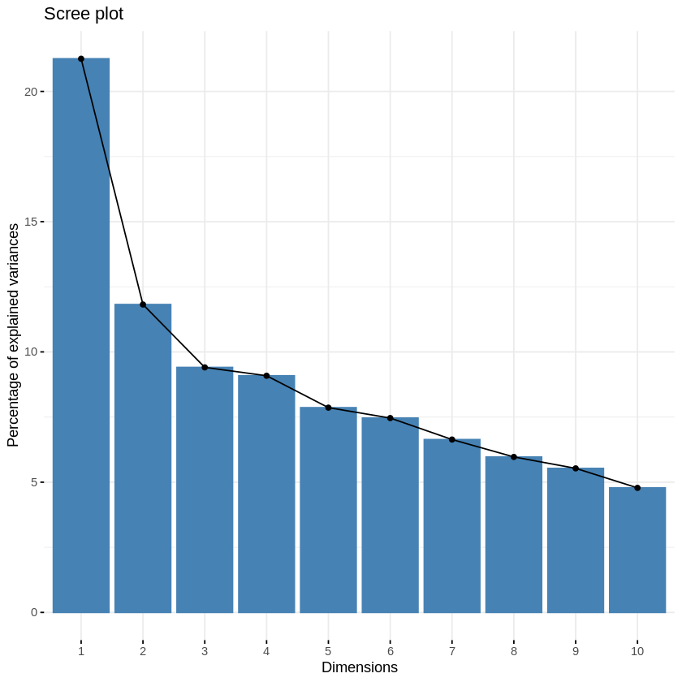

```r
library(factoextra)
res.pca <- prcomp(heart_data[c(1:length(heart_data) - 1)], scale = TRUE)
fviz_eig(res.pca)
```

Organizar la información en los componentes principales de esta manera, le permite reducir la dimensionalidad sin perder mucha información, descartando los componentes con poca información y considerando los componentes restantes como nuevas variables.

Una cosa importante a tener en cuenta aquí es que, los componentes principales son menos interpretables y no tienen ningún significado real, ya que se construyen como combinaciones lineales de las variables iniciales.

Desde la perspectiva geométrica, los componentes principales representan las direcciones de los datos que explican una cantidad máxima de variación. Es decir, las líneas que capturan la mayor parte de la información de los datos. La relación entre la varianza y la información aquí es, cuanto mayor sea la varianza transportada por una línea, mayor será la dispersión de los puntos de datos a lo largo de ella, y cuanto mayor sea la dispersión a lo largo de una línea, más información tendrá. En resumen, los componentes principales como nuevos ejes que proporcionan el mejor ángulo para ver y evaluar los datos, de modo que las diferencias entre las observaciones sean más visibles.

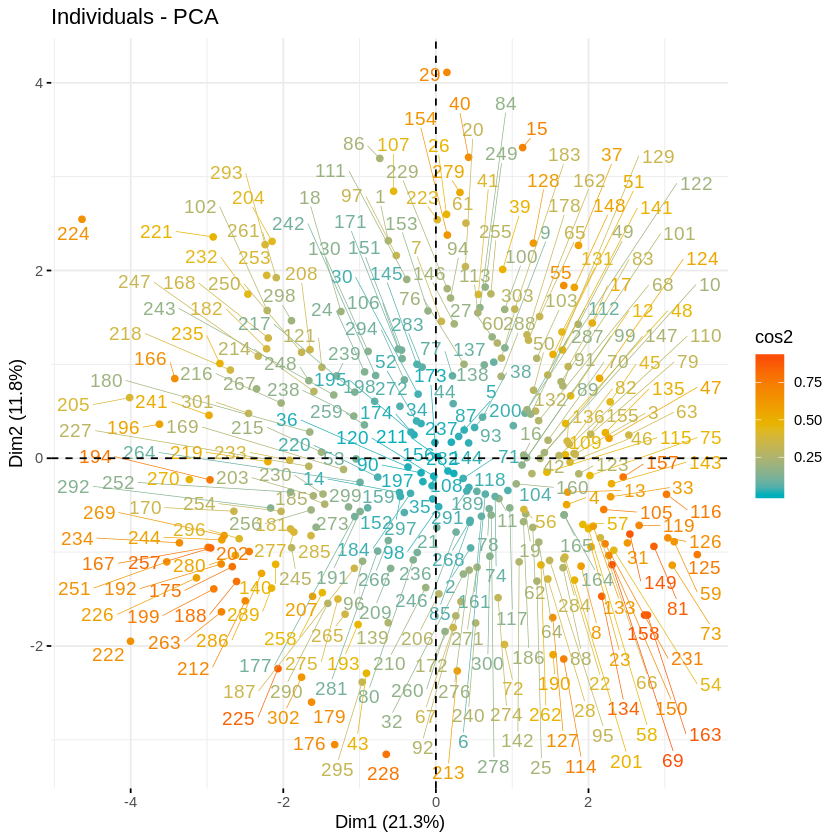

```r
fviz_pca_ind(
    res.pca,
     col.ind = "cos2", # Color by the quality of representation
     gradient.cols = c("#00AFBB", "#E7B800", "#FC4E07"),
     repel = TRUE     # Avoid text overlapping
)
```

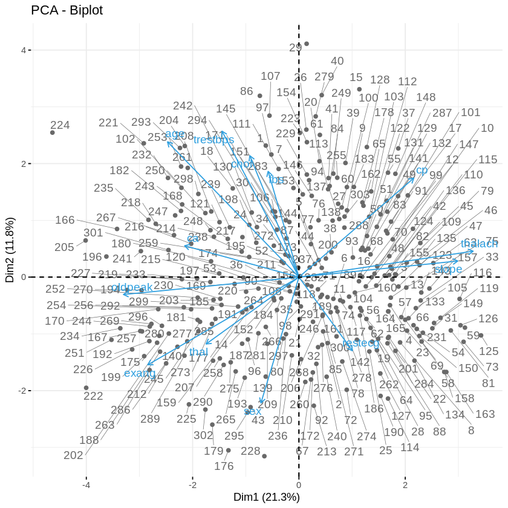

```r
fviz_pca_biplot(
    res.pca,
    repel = TRUE,
    col.var = "#2E9FDF", # Variables color
    col.ind = "#696969"  # Individuals color
)
```

**4. Vectores de Características**

En el paso anterior, se calculan los vectores propios y se ordenan por sus valores propios en orden descendente, donde se encuentran los componentes principales de acuerdo al orden de importancia. En este paso, lo que se hace es elegir si mantener todos estos componentes o descartar aquellos de menor importancia (de valores propios bajos), y formar con los restantes una matriz de vectores que llamamos vector característico o vector de características. En la siguientes tablas se pueden apreciar las forman en las cuales se muestran los valores propios y los vectores propios.

```r
# Eigenvalues
eig.val <- get_eigenvalue(res.pca)
eig.val
```

|  | eigenvalue | variance.percent | cumulative.variance.percent |
| --- | --- | --- | --- |
| Dim.1 | 2.7630269 | 21.254053 | 21.25405 |
| Dim.2 | 1.5366920 | 11.820708 | 33.07476 |
| Dim.3 | 1.2228343 | 9.406418 | 42.48118 |
| Dim.4 | 1.1811455 | 9.085735 | 51.56691 |
| Dim.5 | 1.0219665 | 7.861281 | 59.42819 |
| Dim.6 | 0.9700159 | 7.461661 | 66.88985 |
| Dim.7 | 0.8627699 | 6.636692 | 73.52655 |
| Dim.8 | 0.7759454 | 5.968811 | 79.49536 |
| Dim.9 | 0.7189255 | 5.530196 | 85.02555 |
| Dim.10 | 0.6215702 | 4.781309 | 89.80686 |
| Dim.11 | 0.5301048 | 4.077729 | 93.88459 |
| Dim.12 | 0.4231424 | 3.254941 | 97.13953 |
| Dim.13 | 0.3718607 | 2.860467 | 100.00000 |

**5. Creación de los ejes de componentes principales**

En este paso, el objetivo es utilizar el vector de características formado utilizando los vectores propios de la matriz de covarianza, para reorientar los datos de los ejes originales a los representados por los componentes principales (de ahí el nombre Análisis de componentes principales). Esto se puede hacer multiplicando la transposición del conjunto de datos original por la transposición del vector de características. El resultado se puede ver en el último.

```r
# Results for Variables
res.var <- get_pca_var(res.pca)
res.var$coord          # Coordinates
res.var$contrib        # Contributions to the PCs
res.var$cos2           # Quality of representation

# Results for individuals
res.ind <- get_pca_ind(res.pca)
res.ind$coord          # Coordinates
res.ind$contrib        # Contributions to the PCs

res.ind$cos2           # Quality of representation
```

|  | Dim.1 | Dim.2 | Dim.3 | Dim.4 | Dim.5 | Dim.6 | Dim.7 | Dim.8 | Dim.9 | Dim.10 | Dim.11 | Dim.12 | Dim.13 |
| --- | --- | --- | --- | --- | --- | --- | --- | --- | --- | --- | --- | --- | --- |
| age | -0.5222786 | 0.50347568 | -0.10403165 | 0.02245535 | -0.31050834 | 0.12635808 | -0.20781270 | 0.23121029 | 0.32135233 | 0.01318391 | 0.10232747 | 0.356623609 | -0.110868946 |
| sex | -0.1509939 | -0.46832338 | 0.61356239 | 0.27747086 | 0.05125827 | -0.05413838 | -0.15094513 | 0.15502736 | 0.16866763 | -0.42228057 | 0.20939678 | -0.007165863 | -0.037160278 |
| cp | 0.4564623 | 0.36850110 | 0.39474876 | -0.31289166 | 0.16496196 | 0.19048947 | -0.20006550 | -0.04223802 | 0.29797765 | -0.12957414 | -0.43268785 | -0.063233402 | -0.003872627 |
| trestbps | -0.3057187 | 0.54319112 | 0.22542031 | -0.02456292 | 0.19019324 | 0.17674887 | 0.30908860 | 0.52441625 | -0.29709536 | -0.05638954 | 0.04669223 | -0.168296717 | -0.012275108 |
| chol | -0.1951050 | 0.45186391 | -0.45098036 | 0.37321957 | 0.32356298 | 0.10314751 | 0.04581978 | -0.32802166 | 0.13055476 | -0.39039054 | 0.07926901 | -0.119554596 | 0.004544934 |
| fbs | -0.1224070 | 0.39350103 | 0.53271279 | 0.07456062 | -0.23599187 | -0.24584293 | 0.47447559 | -0.38129934 | 0.15008107 | 0.12117328 | 0.10346256 | 0.016086449 | 0.077546875 |
| restecg | 0.2123139 | -0.27381256 | -0.09862886 | -0.28919402 | -0.39796753 | 0.65674039 | 0.36865838 | -0.08794753 | 0.03247805 | -0.21284021 | 0.06956451 | -0.001752676 | -0.045395172 |
| thalach | 0.6923180 | 0.09653795 | 0.17500161 | 0.20010843 | 0.32681574 | 0.11915684 | 0.09425327 | -0.12637183 | -0.31545457 | -0.02429260 | 0.02366763 | 0.396093132 | -0.193119882 |
| exang | -0.6005116 | -0.32616984 | -0.13972690 | 0.12504368 | 0.03491293 | -0.22721416 | 0.41790872 | 0.09919259 | 0.04960204 | -0.15667965 | -0.44842721 | 0.155519185 | -0.090694139 |
| oldpeak | -0.6975388 | -0.06477703 | 0.12201921 | -0.35462015 | 0.25331650 | 0.16751058 | -0.10485631 | -0.16941320 | -0.19807071 | -0.08781497 | 0.01109732 | 0.221709549 | 0.374770471 |
| slope | 0.6312709 | 0.05996623 | -0.08162973 | 0.53780439 | -0.24951895 | 0.06310151 | 0.05112224 | 0.23061996 | 0.02416898 | -0.04409797 | -0.12289875 | 0.086883868 | 0.393423342 |
| ca | -0.4542253 | 0.11670806 | 0.20299435 | 0.35648984 | -0.44012091 | 0.17935655 | -0.31358672 | -0.22874481 | -0.41191443 | -0.02785011 | -0.21605095 | -0.094991882 | -0.095290409 |
| thal | -0.3690558 | -0.24881981 | 0.13823961 | 0.42297521 | 0.33557659 | 0.50116967 | 0.05124006 | -0.03025708 | 0.24097261 | 0.41850590 | -0.03175241 | -0.047221429 | -0.009567644 |

|  | Dim.1 | Dim.2 | Dim.3 | Dim.4 | Dim.5 | Dim.6 | Dim.7 | Dim.8 | Dim.9 | Dim.10 | Dim.11 | Dim.12 | Dim.13 |
| --- | --- | --- | --- | --- | --- | --- | --- | --- | --- | --- | --- | --- | --- |
| age | 9.8723226 | 16.4956780 | 0.8850409 | 0.04269101 | 9.4343041 | 1.6459901 | 5.0055194 | 6.8894280 | 14.36411969 | 0.02796394 | 1.97525299 | 3.005617e+01 | 3.305517971 |
| sex | 0.8251512 | 14.2726576 | 30.7857576 | 6.51825495 | 0.2570936 | 0.3021563 | 2.6408467 | 3.0973161 | 3.95712337 | 28.68877601 | 8.27138628 | 1.213530e-02 | 0.371345016 |
| cp | 7.5409275 | 8.8367129 | 12.7430660 | 8.28866463 | 2.6627532 | 3.7407879 | 4.6392673 | 0.2299196 | 12.35046975 | 2.70113624 | 35.31731678 | 9.449451e-01 | 0.004033026 |
| trestbps | 3.3826637 | 19.2007630 | 4.1554538 | 0.05108065 | 3.5395941 | 3.2205827 | 11.0731446 | 35.4422370 | 12.27744077 | 0.51157213 | 0.41127040 | 6.693677e+00 | 0.040520081 |
| chol | 1.3776899 | 13.2870472 | 16.6321213 | 11.79303041 | 10.2442693 | 1.0968284 | 0.2433386 | 13.8667247 | 2.37083628 | 24.51931873 | 1.18534619 | 3.377894e+00 | 0.005554883 |
| fbs | 0.5422848 | 10.0763888 | 23.2069802 | 0.47066905 | 5.4495094 | 6.2306968 | 26.0935245 | 18.7370387 | 3.13305465 | 2.36223742 | 2.01931792 | 6.115526e-02 | 1.617142477 |
| restecg | 1.6314420 | 4.8788775 | 0.7955005 | 7.08068391 | 15.4973918 | 44.4640093 | 15.7526353 | 0.9968185 | 0.14672229 | 7.28814794 | 0.91288002 | 7.259669e-04 | 0.554164909 |
| thalach | 17.3470677 | 0.6064700 | 2.5044738 | 3.39021587 | 10.4512745 | 1.4637237 | 1.0296694 | 2.0581140 | 13.84171003 | 0.09494192 | 0.10566909 | 3.707730e+01 | 10.029370123 |
| exang | 13.0514172 | 6.9231028 | 1.5965864 | 1.32379306 | 0.1192713 | 5.3222093 | 20.2426733 | 1.2680236 | 0.34222767 | 3.94943525 | 37.93343793 | 5.715858e+00 | 2.211964350 |
| oldpeak | 17.6096880 | 0.2730582 | 1.2175556 | 10.64690595 | 6.2789969 | 2.8927151 | 1.2743659 | 3.6988213 | 5.45703380 | 1.24064334 | 0.02323134 | 1.161669e+01 | 37.770297980 |
| slope | 14.4226939 | 0.2340058 | 0.5449154 | 24.48754714 | 6.0921472 | 0.4104882 | 0.3029178 | 6.8542924 | 0.08125175 | 0.31285780 | 2.84926764 | 1.783987e+00 | 41.623627667 |
| ca | 7.4671967 | 0.8863697 | 3.3697703 | 10.75947060 | 18.9542817 | 3.3163140 | 11.3977816 | 6.7432821 | 23.60098418 | 0.12478533 | 8.80543164 | 2.132487e+00 | 2.441844825 |
| thal | 4.9294546 | 4.0288685 | 1.5627783 | 15.14699276 | 11.0191129 | 25.8934981 | 0.3043156 | 0.1179839 | 8.07702577 | 28.17818398 | 0.19019177 | 5.269771e-01 | 0.024616693 |

|  | Dim.1 | Dim.2 | Dim.3 | Dim.4 | Dim.5 | Dim.6 | Dim.7 | Dim.8 | Dim.9 | Dim.10 | Dim.11 | Dim.12 | Dim.13 |
| --- | --- | --- | --- | --- | --- | --- | --- | --- | --- | --- | --- | --- | --- |
| age | 0.27277493 | 0.253487765 | 0.010822583 | 0.0005042429 | 0.096415431 | 0.015966365 | 0.043186116 | 0.0534581985 | 0.1032673199 | 0.0001738155 | 0.0104709102 | 1.271804e-01 | 1.229192e-02 |
| sex | 0.02279915 | 0.219326789 | 0.376458803 | 0.0769900759 | 0.002627411 | 0.002930964 | 0.022784431 | 0.0240334808 | 0.0284487691 | 0.1783208783 | 0.0438470127 | 5.134960e-05 | 1.380886e-03 |
| cp | 0.20835786 | 0.135793060 | 0.155826582 | 0.0979011903 | 0.027212447 | 0.036286236 | 0.040026203 | 0.0017840506 | 0.0887906769 | 0.0167894575 | 0.1872187790 | 3.998463e-03 | 1.499724e-05 |
| trestbps | 0.09346391 | 0.295056589 | 0.050814314 | 0.0006033369 | 0.036173467 | 0.031240163 | 0.095535761 | 0.2750124000 | 0.0882656530 | 0.0031797798 | 0.0021801640 | 2.832378e-02 | 1.506783e-04 |
| chol | 0.03806594 | 0.204180992 | 0.203383285 | 0.1392928495 | 0.104693004 | 0.010639409 | 0.002099452 | 0.1075982096 | 0.0170445467 | 0.1524047749 | 0.0062835766 | 1.429330e-02 | 2.065643e-05 |
| fbs | 0.01498348 | 0.154843061 | 0.283782914 | 0.0055592863 | 0.055692163 | 0.060438748 | 0.225127082 | 0.1453891856 | 0.0225243289 | 0.0146829635 | 0.0107045005 | 2.587738e-04 | 6.013518e-03 |
| restecg | 0.04507718 | 0.074973320 | 0.009727653 | 0.0836331803 | 0.158378159 | 0.431307945 | 0.135909000 | 0.0077347673 | 0.0010548239 | 0.0453009547 | 0.0048392205 | 3.071873e-06 | 2.060722e-03 |
| thalach | 0.47930415 | 0.009319576 | 0.030625564 | 0.0400433827 | 0.106808529 | 0.014198352 | 0.008883678 | 0.0159698406 | 0.0995115836 | 0.0005901306 | 0.0005601569 | 1.568898e-01 | 3.729529e-02 |
| exang | 0.36061417 | 0.106386767 | 0.019523606 | 0.0156359223 | 0.001218913 | 0.051626275 | 0.174647698 | 0.0098391707 | 0.0024603620 | 0.0245485120 | 0.2010869618 | 2.418622e-02 | 8.225427e-03 |
| oldpeak | 0.48656042 | 0.004196064 | 0.014888687 | 0.1257554518 | 0.064169247 | 0.028059796 | 0.010994845 | 0.0287008331 | 0.0392320078 | 0.0077114691 | 0.0001231505 | 4.915512e-02 | 1.404529e-01 |
| slope | 0.39850291 | 0.003595949 | 0.006663413 | 0.2892335642 | 0.062259706 | 0.003981800 | 0.002613483 | 0.0531855648 | 0.0005841396 | 0.0019446308 | 0.0151041035 | 7.548807e-03 | 1.547819e-01 |
| ca | 0.20632066 | 0.013620772 | 0.041206707 | 0.1270850042 | 0.193706417 | 0.032168772 | 0.098336632 | 0.0523241859 | 0.1696734946 | 0.0007756284 | 0.0466780127 | 9.023458e-03 | 9.080262e-03 |
| thal | 0.13620216 | 0.061911300 | 0.019110189 | 0.1789080252 | 0.112611646 | 0.251171040 | 0.002625544 | 0.0009154908 | 0.0580677983 | 0.1751471905 | 0.0010082156 | 2.229863e-03 | 9.153981e-05 |

[output not shown]

[output not shown]

[output not shown]

### Naive-Bayes

Naive Bayes es un modelo estadístico basado en el teorema de Bayes que se utiliza para resolver problemas de clasificación siguiendo un enfoque probabilístico. Se basa en la idea de que las variables predictoras en un modelo de aprendizaje automático son independientes entre sí. Lo que significa que el resultado de un modelo depende de un conjunto de variables independientes que no tienen nada que ver entre sí.

Las variables predictoras no siempre son independientes entre sí, siempre hay algunas correlaciones entre ellas. Dado que Naive Bayes considera que cada variable predictiva es independiente de cualquier otra variable en el modelo, se le llama *Naive*.

El principio detrás de Naive Bayes es el teorema de Bayes, también conocido como la Regla de Bayes. El teorema se usa para calcular la probabilidad condicional, que no es más que la probabilidad de que ocurra un evento en base a la información sobre los eventos del pasado. Estadísticamente se represeta como:

$$ P(A|B) = \frac{P(B|A)P(A)}{P(B)} $$

Donde:

- P(A|B): probabilidad condicional de que ocurra el evento A, dado el evento B
- P(A): Probabilidad de que ocurra el evento A
- P(B): Probabilidad de que ocurra el evento B
- P(B|A): probabilidad condicional de que ocurra el evento B, dado el evento A Formalmente, las terminologías del Teorema bayesiano son las siguientes:

A se conoce como la proposición y B es la evidencia.

- P(A) representa la probabilidad previa de la proposición
- P(B) representa la probabilidad previa de evidencia
- P(A|B) se llama la posterior
- P(B|A) es la probabilidad

Por lo tanto, el teorema de Bayes se puede resumir como:

Posterior = (Probabilidad) (Probabilidad previa de la proposición) / Probabilidad previa probatoria

También se puede considerar de la siguiente manera:

Dada una hipótesis H y evidencia E, el teorema de Bayes establece que la relación entre la probabilidad de hipótesis antes de obtener la evidencia P(H) y la probabilidad de la hipótesis después de obtener la evidencia P(H|E) es:

$$ P(H|E) = \frac{P(E|H)P(H)}{P(E)} $$

Derivación del teorema de Bayes El objetivo principal del Teorema de Bayes es calcular la probabilidad condicional. La regla de Bayes se puede derivar de las siguientes dos ecuaciones:

La siguiente ecuación representa la probabilidad condicional de A, dada B:

$$ P(A|B) = \frac{P(A\bigcap B)}{P(B)}$$

La siguiente ecuación representa la probabilidad condicional de B, dada A:

$$ P(B|A) = \frac{P(B\bigcap A)}{P(A)} $$

Por lo tanto, al combinar las dos ecuaciones anteriores obtenemos el Teorema de Bayes:

$$ P(A|B) = \frac{P(B|A)P(A)}{P(B)} $$

La ecuación anterior fue para una sola variable predictiva, sin embargo, en las aplicaciones del mundo real, hay más de una variable predictiva y para un problema de clasificación, hay más de una clase de salida. Las clases se pueden representar como, C1, C2, ..., Ck y las variables predictoras se pueden representar como un vector, x1, x2, ..., xn.

El objetivo de un algoritmo Naive Bayes es medir la probabilidad condicional de un evento con un vector de características x1, x2, ..., xn perteneciente a una clase particular Ci,

$$ P(C_i|x_1, ..., x_n) = \frac{P(x_1, ..., x_n)P(C_i)}{P(x_1, ..., x_n))} \text{for } 1 < i < k $$

#### Implementación de Naive-Bayes

##### Preprocesamiento

[output not shown]

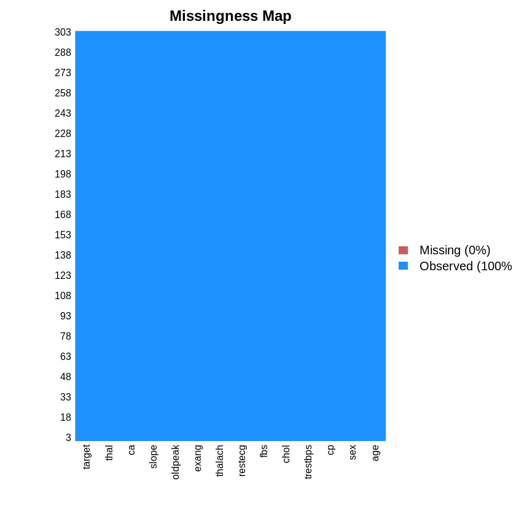

```r
library(Rcpp)
library(Amelia)
missmap(heart_data)
```

Primero verificamos que no haya valores faltantes así como en la gráfica anterior.

##### Selección de Características

```r
library(caret)
heart_data$target <- factor(heart_data$target)
indxTrain <- createDataPartition(y = heart_data$target,p = 0.80,list = FALSE)
training <- data[indxTrain,]
testing <- data[-indxTrain,]
```

**Análisis de la distribución de los datos**

```r
prop.table(table(heart_data$target)) * 100
```

```
       0        1
45.54455 54.45545
```

```r
prop.table(table(training$target)) * 100
```

```
       0        1
45.67901 54.32099
```

```r
prop.table(table(testing$target)) * 100
```

```
 0  1
45 55
```

```r
x = training[,-14]
y = factor(training$target)
```

**Uso de Naive Bayes como classificador**

```r
model = train(x,y,'nb',trControl=trainControl(method='cv',number=10))
model
```

```
Naive Bayes

243 samples
 13 predictor
  2 classes: '0', '1'

No pre-processing
Resampling: Cross-Validated (10 fold)
Summary of sample sizes: 219, 218, 219, 219, 218, 219, ...
Resampling results across tuning parameters:

  usekernel  Accuracy   Kappa
  FALSE      0.8068333  0.6080141
   TRUE      0.8073333  0.6067460

Tuning parameter 'fL' was held constant at a value of 0
Tuning
 parameter 'adjust' was held constant at a value of 1
Accuracy was used to select the optimal model using the largest value.
The final values used for the model were fL = 0, usekernel = TRUE and adjust
 = 1.
```

##### Evaluación del Modelo

```r
pred <- predict(model,newdata = testing )
confusionMatrix(pred, factor(testing$target) )
```

```
Confusion Matrix and Statistics

          Reference
Prediction  0  1
         0 22  1
         1  5 32

               Accuracy : 0.9
                 95% CI : (0.7949, 0.9624)
    No Information Rate : 0.55
    P-Value [Acc > NIR] : 4.558e-09

                  Kappa : 0.7952
 Mcnemar's Test P-Value : 0.2207

            Sensitivity : 0.8148
            Specificity : 0.9697
         Pos Pred Value : 0.9565
         Neg Pred Value : 0.8649
             Prevalence : 0.4500
         Detection Rate : 0.3667
   Detection Prevalence : 0.3833
      Balanced Accuracy : 0.8923

       'Positive' Class : 0
```

```r
norm_data <- data.frame(cbind(res.ind$cos2, target=heart_data$target))
indxTrain <- createDataPartition(y = norm_data$target,p = 0.80,list = FALSE)
ntraining <- data[indxTrain,]
ntesting <- data[-indxTrain,]
```

```r
nx = training[,-14]
ny = factor(training$target)
```

```r
nmodel = train(nx, ny,'nb',trControl=trainControl(method='cv',number=10))
nmodel
```

```
Naive Bayes

243 samples
 13 predictor
  2 classes: '0', '1'

No pre-processing
Resampling: Cross-Validated (10 fold)
Summary of sample sizes: 218, 219, 219, 219, 219, 217, ...
Resampling results across tuning parameters:

  usekernel  Accuracy   Kappa
  FALSE      0.8017821  0.5982749
   TRUE      0.8056282  0.6046254

Tuning parameter 'fL' was held constant at a value of 0
Tuning
 parameter 'adjust' was held constant at a value of 1
Accuracy was used to select the optimal model using the largest value.
The final values used for the model were fL = 0, usekernel = TRUE and adjust
 = 1.
```

```r
pred1 <- predict(nmodel,newdata = ntesting )
confusionMatrix(pred1, factor(ntesting$target) )
```

```
Confusion Matrix and Statistics

          Reference
Prediction  0  1
         0 28  0
         1  5 27

               Accuracy : 0.9167
                 95% CI : (0.8161, 0.9724)
    No Information Rate : 0.55
    P-Value [Acc > NIR] : 5.918e-10

                  Kappa : 0.8344
 Mcnemar's Test P-Value : 0.07364

            Sensitivity : 0.8485
            Specificity : 1.0000
         Pos Pred Value : 1.0000
         Neg Pred Value : 0.8437
             Prevalence : 0.5500
         Detection Rate : 0.4667
   Detection Prevalence : 0.4667
      Balanced Accuracy : 0.9242

       'Positive' Class : 0
```

**Comentarios:** El PCA calcula una nueva proyección del conjunto de datos, dando paso a nuevos ejes basados en la desviación estándar de las variables del conjunto de datos. Antes de inicializar el PCA se realiza una normalización Z con el fin de evitar la sobreestimación, así como evitar los problemas con los valores atípicos. De nos er así, una variable con una desviación estándar alta tendrá un peso mayor para el cálculo del eje que una variable con una desviación estándar baja.

## Referencias

1. Dua, D. and Graff, C. (2019). UCI Machine Learning Repository [http://archive.ics.uci.edu/ml]. Irvine, CA: University of California, School of Information and Computer Science.
2. Detrano, R., Janosi, A., Steinbrunn, W., Pfisterer, M., Schmid, J., Sandhu, S., Guppy, K., Lee, S., & Froelicher, V. (1989). International application of a new probability algorithm for the diagnosis of coronary artery disease. American Journal of Cardiology, 64,304--310.
3. David W. Aha & Dennis Kibler. "Instance-based prediction of heart-disease presence with the Cleveland database."
4. Walpole, R. E., Myers, R. H., & Myers, S. L. (2007). Probabilidad y estadística para ingeniería y ciencias (8a. ed.). Distrito Federal: Pearson Educación.
5. DeGroot, M. H., & Schervish, M. J. (2019). Probability and statistics.
6. James, G. (2017). An introduction to statistical learning: With applications in R. New York: Springer.
7. Hastie, T., Tibshirani, R., & Friedman, J. (2009). The Elements of Statistical Learning. Dordrecht: Springer.